# Predicting Weight Lifting Classes

Johnny Edwards

November 22, 2015

## Background

Using devices such as Jawbone Up, Nike FuelBand, and Fitbit it is now possible to collect a large amount of data about personal activity relatively inexpensively. These type of devices are part of the quantified self movement - a group of enthusiasts who take measurements about themselves regularly to improve their health, to find patterns in their behavior, or because they are tech geeks. One thing that people regularly do is quantify how much of a particular activity they do, but they rarely quantify how well they do it.

## Goal

An exception is the data available at this website http://groupware.les.inf.puc-rio.br/har (see the section on the Weight Lifting Exercise Dataset).

Here 6 volounteers were asked to perform barbell lifts correctly and incorrectly in 5 different ways. The data from accelerometers on the belt, forearm, arm, and dumbell of 6 participants were recorded as well as the correct or incorrect way of lifting.

The goal of this project is to show that it is possible to predict the type of lifting (the ‘classe’) from the data from the accelerometers.

## Model selection

Tree based models are good at performing this type of analysis. A simple binary tree would be the most interpretable. However, the goal is to achieve good predictive power so I decided that I would use a random forest model. This has a very good reputation at solving these types of problems and there are many good out the the box libraries available.

I will estimate the out of sample error rate using a validation set and stick with the random forest model if this seems good enough to predict the 20 unknown samples.

## Libraries used

The machine learning is done using R and the following libraries.

```r
library(ggplot2,      quietly=TRUE, warn.conflicts = FALSE)
library(caret,          quietly=TRUE, warn.conflicts = FALSE)
library(randomForest,   quietly=TRUE, warn.conflicts = FALSE)
```

## Getting the data

The training and testing data (‘pml-training.csv’ and ‘pml-testing.csv’) for this project were downloaded from the following locations.

- https://d396qusza40orc.cloudfront.net/predmachlearn/pml-training.csv
- https://d396qusza40orc.cloudfront.net/predmachlearn/pml-testing.csv

After downloading the data we read it in as follows.

```r
training <- read.csv("pml-training.csv")
testing <- read.csv("pml-testing.csv")
```

These are the dimensions of the data sets.

```r
dim(training)
```

```
## [1] 19622   160
```

```r
dim(testing)
```

```
## [1]  20 160
```

## Cleaning and choosing features

The first task is to tidy up the data and to identify the features that we will use for predicting the class.

I performed the following cleaning.

- I first deleted an indexing column ‘x’ . This was an index variable. It would only confuse any machine learning algorithm as it has no connection with the testing variable of the same name.
- I then deleted all columns from the training data that were hardly used (missing from 97% or more of the observations).
- I finally deleted the name of the weight-lifter and timestamps of the measurements. They would not be available in any production version of the algorithm. I therefore considered it in the spirit of the assignment to exclude them (although strictly speaking they were allowed).

This leaves the following 52 predictor variables plus the predictor variable ’classe; in the training set.

```r
names(training)
```

```
##  [1] "roll_belt"            "pitch_belt"           "yaw_belt"
##  [4] "total_accel_belt"     "gyros_belt_x"         "gyros_belt_y"
##  [7] "gyros_belt_z"         "accel_belt_x"         "accel_belt_y"
## [10] "accel_belt_z"         "magnet_belt_x"        "magnet_belt_y"
## [13] "magnet_belt_z"        "roll_arm"             "pitch_arm"
## [16] "yaw_arm"              "total_accel_arm"      "gyros_arm_x"
## [19] "gyros_arm_y"          "gyros_arm_z"          "accel_arm_x"
## [22] "accel_arm_y"          "accel_arm_z"          "magnet_arm_x"
## [25] "magnet_arm_y"         "magnet_arm_z"         "roll_dumbbell"
## [28] "pitch_dumbbell"       "yaw_dumbbell"         "total_accel_dumbbell"
## [31] "gyros_dumbbell_x"     "gyros_dumbbell_y"     "gyros_dumbbell_z"
## [34] "accel_dumbbell_x"     "accel_dumbbell_y"     "accel_dumbbell_z"
## [37] "magnet_dumbbell_x"    "magnet_dumbbell_y"    "magnet_dumbbell_z"
## [40] "roll_forearm"         "pitch_forearm"        "yaw_forearm"
## [43] "total_accel_forearm"  "gyros_forearm_x"      "gyros_forearm_y"
## [46] "gyros_forearm_z"      "accel_forearm_x"      "accel_forearm_y"
## [49] "accel_forearm_z"      "magnet_forearm_x"     "magnet_forearm_y"
## [52] "magnet_forearm_z"     "classe"
```

I did not perform any transformations on the data as these are not usually needed for tree-based algorithms.

## Splitting the training data

I then split the training data (70/30) into a training set and cross validation set. The latter would be used to evaluate a model that is trained using the training data.

```r
inTrain <- createDataPartition(training$classe, p = .7, list = FALSE)
trainMod <- training[inTrain,]
validMod <- training[-inTrain,]
```

These are the dimensions now.

```r
dim(trainMod)
```

```
## [1] 13737    53
```

```r
dim(validMod)
```

```
## [1] 5885   53
```

## Model training

I trained a random forest model using the training data. I used cv with 3 folds to speed up the computation. In fact, experimentation showed that it was just as accurate as the more time consuming default options (bootstrap resampling with 25 repetitions).

```r
mytrControl <- trainControl(method = "cv", number = 3)
system.time(
    trainRF <- train(classe~., data=trainMod, method="rf",
                     trControl=mytrControl)
)
```

```
##    user  system elapsed
##  272.32    1.17  273.56
```

```r
print(trainRF)
```

```
## Random Forest
##
## 13737 samples
##    52 predictor
##     5 classes: 'A', 'B', 'C', 'D', 'E'
##
## No pre-processing
## Resampling: Cross-Validated (3 fold)
## Summary of sample sizes: 9158, 9159, 9157
## Resampling results across tuning parameters:
##
##   mtry  Accuracy   Kappa      Accuracy SD  Kappa SD
##    2    0.9874789  0.9841587  0.002416358  0.003060685
##   27    0.9882797  0.9851726  0.001534854  0.001944147
##   52    0.9812913  0.9763322  0.001754152  0.002215844
##
## Accuracy was used to select the optimal model using  the largest value.
## The final value used for the model was mtry = 27.
```

## Cross validation and expected out of sample error

We have kept back our own validation set to perform an independent estimate of the model’s accuracy. We ask the model to predict the outcome on the validation set:

```r
pred.valid.RF<-predict(trainRF, validMod)
```

We place this information in a confusion matrix. This summarizes how the model did on the validation set. We also output the accuracy (= #good predictions/ #predictions). This is a good measure of the prediction quality as the outcomes are fairly evenly spread over the 5 classes.

```r
confuse.RF  <-confusionMatrix(pred.valid.RF, validMod$classe)
confuse.RF$table
```

```
##           Reference
## Prediction    A    B    C    D    E
##          A 1674    9    0    0    0
##          B    0 1130    5    1    0
##          C    0    0 1016    9    4
##          D    0    0    5  954    2
##          E    0    0    0    0 1076
```

```r
confuse.RF$overall["Accuracy"]
```

```
##  Accuracy
## 0.9940527
```

We are interested in whether the model will make a good stab at the test data. We are in fact 88.7% confident that the model will get all the test observations correct (as p^20=0.887, where p=0.994).

## Test set predictions

The final step is to make the predictions on the test data. Here they are.

```r
answer <-predict(trainRF, testing)
print(answer)
```

```
##  [1] B A B A A E D B A A B C B A E E A B B B
## Levels: A B C D E
```

This is the correct result for all 20 observations!

## Appendix - Important variables

One nice feature of the random forest is that it is able to indicate the importance of the predictor variables in the model. Here are the top 20.

```r
varImp(trainRF)
```

```
## rf variable importance
##
##   only 20 most important variables shown (out of 52)
##
##                      Overall
## roll_belt            100.000
## pitch_forearm         57.870
## yaw_belt              51.472
## magnet_dumbbell_y     42.439
## magnet_dumbbell_z     42.119
## pitch_belt            41.754
## roll_forearm          41.029
## accel_dumbbell_y      21.758
## roll_dumbbell         17.428
## magnet_dumbbell_x     16.919
## accel_forearm_x       16.131
## magnet_belt_z         15.517
## magnet_forearm_z      13.372
## accel_dumbbell_z      13.241
## accel_belt_z          13.051
## total_accel_dumbbell  12.812
## magnet_belt_y         11.804
## gyros_belt_z          11.691
## yaw_arm               10.764
## magnet_belt_x          9.905
```

For instance, the following plot demonstates the potential of the roll and pitch of the belt in predicting the classe. With 52 such predictors there is a very good chance of predicting the correct class with high likelihood. This was verified in this assignment!

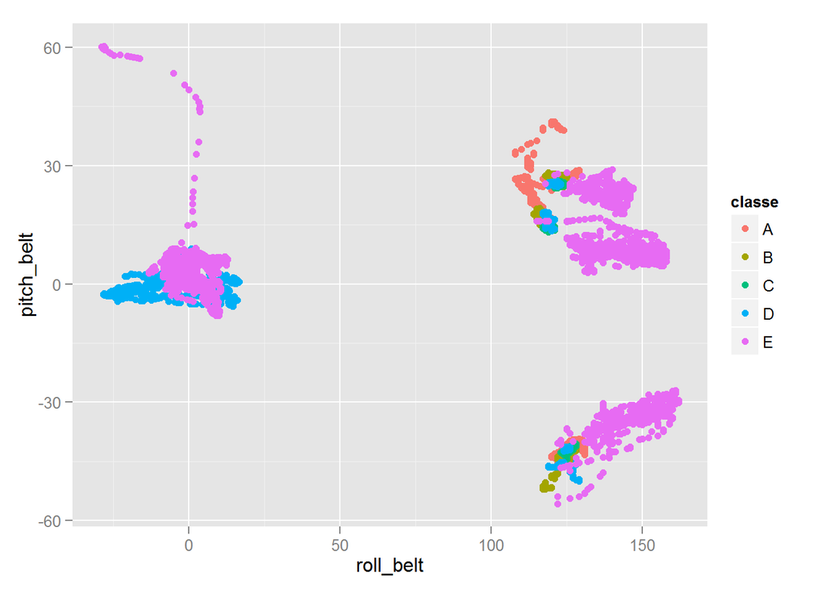